# Proctor Data Analysis Assessment

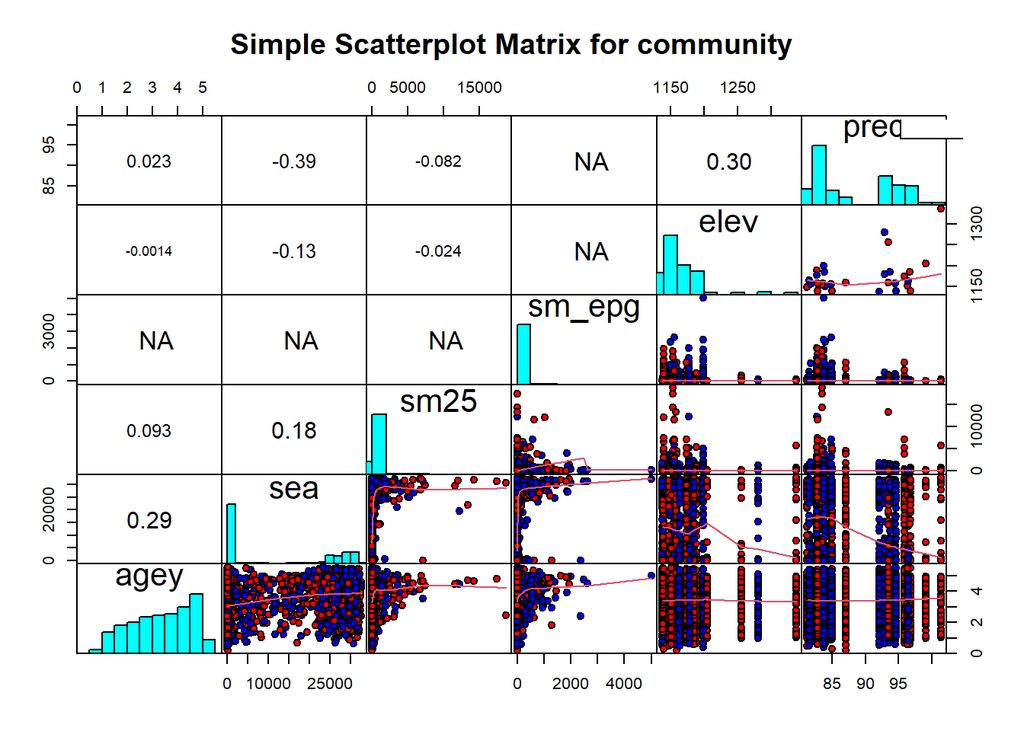

```r
# The four geographical variables show a strong correlation, particularly the distance from the lake (dist_victoria) which is strongly correlated with the other three variables with all correlation coefficients exceeding 0.5. The variable is negatively correlated with the minimum temperature, meaning that the farther the distance from the lake, the lower the temperature. There is also a strong negative correlation between temperature and the other two variables of altitude and precipitation: the higher the altitude, the lower the temperature, and the more precipitation. However, there is no clear relationship between altitude and precipitation. The strong correlation among variables may lead to collinearity problems when building models, which should be addressed.On the other hand, there is a weak correlation between age and the four geographical variables, suggesting that children of all ages are distributed across each region.


     pairs(~agey+sea+sm25+sm_epg+elev+prec,
          main="Simple Scatterplot Matrix for community",
          pch = 21,
          # panel = panel.smooth,
          lower.panel = panel.smooth,
          upper.panel = panel.cor,
          gap=0,
          row1attop=FALSE,
          diag.panel = panel.hist,
          bg = c("red", "blue")[unclass(complete$arm)])

    legend("topright", c("CWT", "SBT"), col= c("red", "blue"), pch=1)
```

```r
# After reviewing the previous plots, two environmental variables and two variables related to the children were selected to create a graph. The graph shows a weak negative correlation between altitude and the child-related variables. This suggests that the higher the altitude, the lower the positive response, although the correlation is so weak that it can be ignored. Additionally, there is a weak negative correlation between precipitation and the sea variable. This indicates that the more precipitation there is, the lower the positive response value of the sea variable. The relationship between these variables and the other variables is not strong.




#4. Provide some simple descriptive summaries that help describe the data.

    # Group comparison by arm
    library(CBCgrps)
    twogrps(complete[,-c(2,4)], "arm")
```

```
## $Table
##
## 1                      Variables         Total (n = 3663)
## 2                    year, n (%)
## 3                           2012                1120 (31)
## 4                           2013                1187 (32)
## 5                           2014                1356 (37)
## 6           agey, Median (Q1,Q3)         3.5 (2.43, 4.44)
## 7                     sex, n (%)
## 8                              M                1759 (48)
## 9                              F                1904 (52)
## 10           sea, Median (Q1,Q3)         387 (101, 27337)
## 11          sm25, Median (Q1,Q3)             6 (1.15, 19)
## 12        sm_epg, Median (Q1,Q3)                0 (0, 12)
## 13                sea_pos, n (%)
```

[output cut: 49 more lines]

```r
    #Another method for group comparisions with test types & P values
    library(epiDisplay)
    library(data.table)
    dt<-as.data.table(complete)
    tableStack(vars=c(year,agey,sea, sm25,sm_epg,sea_pos,sm25_pos,kk_pos,elev,tmin,prec,dist_victoria), by = arm, dataFrame = dt)
```

```
##               CWT                   SBT                  Test stat.
## Total         1826                  1837
##
## year                                                     Chisq. (2 df) = 11.35
##    2012       538 (29.5)            582 (31.7)
##    2013       563 (30.8)            624 (34)
##    2014       725 (39.7)            631 (34.3)
##
## agey                                                     Ranksum test
##   median(IQR) 3.5 (2.4,4.4)         3.5 (2.4,4.5)
##
## sea                                                      Ranksum test
##   median(IQR) 227.5 (94,26362)      4326 (113,27899)
##
## sm25                                                     Ranksum test
##   median(IQR) 5 (1,18)              6 (2,19)
##
## sm_epg                                                   Ranksum test
##   median(IQR) 0 (0,0)               0 (0,12)
##
## sea_pos                                                  Chisq. (1 df) = 33.8
##    No         1042 (57.1)           872 (47.5)
##    Yes        784 (42.9)            965 (52.5)
##
## sm25_pos                                                 Chisq. (1 df) = 0.44
##    No         1523 (83.4)           1517 (82.6)
##    Yes        303 (16.6)            320 (17.4)
##
## kk_pos                                                   Chisq. (1 df) = 12.74
##    No         1315 (77.3)           1242 (72)
##    Yes        386 (22.7)            483 (28)
##
## elev                                                     Ranksum test
##   median(IQR) 1156 (1147,1174)      1164 (1155,1184)
##
## tmin                                                     Ranksum test
##   median(IQR) 159.1 (156.4,160.8)   158.8 (158.2,160.1)
##
## prec                                                     Ranksum test
##   median(IQR) 87.1 (82.8,95.8)      83.9 (83.6,92.9)
```

[output cut: 33 more lines]

```
##    No
##    Yes
##
## elev          < 0.001
##   median(IQR)
##
## tmin          0.021
##   median(IQR)
##
## prec          < 0.001
##   median(IQR)
##
## dist_victoria 0.008
##   median(IQR)
##
```

```r
# A total of 3663 preschool-aged children were enrolled in the study during 2012 to 2014. Of those enrolled, there were 1826 (49.84%) children in the CWT group, median age of enrollment was 3.5 years (2.43, 4.44, P=0.87) for the total group: for CWT group, the median age was 3.5 (2.45, 4.44), and for the SBT group, it was 3.5 (2.4, 4.45); There were slightly more female enrolled in the group (52%), with 51% for CWT and 53% for SBT. The overall prevalence of S.Mansoni infection with antibody responses to SEA was lower in CWT (43%) compared to SBT (53%) with P< 0.001; the overall prevalence of S.Mansoni infection by Kato-Katz was lower in CWT (23%) compared to SBT (28%) with P< 0.001; In contrast to the SEA results, prevalence of S.Mansoni infection with antibodies to Sm25 between two groups - CWT (17%) and SBT (17%)- are very similar.
```

#3 Summarize baseline characteristics (group comparisons:table 1)

In randomized, controlled trials (RCTs) we use random allocation of treatment to balance measurable and unmeasurable characteristics between treatment groups. On average, the potential outcomes in the two groups should be the same in the absence of treatment any differences we observe in outcomes can be attributed to a treatment effect.One important step in an RCT is to compare groups based on measurable baseline characteristics. This is often Table 1 in reporting for RCTs and is item 15 on the CONSORT checklist for cluster randomized trials.The schistosomiasis study was a community randomized trial so the independent units for analysis are the community.

1. Create a table that summarizes individual-level and cluster-level characteristics by randomized group (community-wide treatment and school-based treatment). Each row should be a variable or level of that variable. There should be a separate column for each group. For measures of S. mansoni infection or antibody response, limit your summary to the categorical measures rather than quantitative measures. For other quantitative variables, summarize the mean and standard deviation (and/or median and interquartile range if you feel that is more appropriate). For categorical variables, report the N and percent.

```r
#  Individual level VS community level-----------------------------------------------------------------

# a table showing baseline characteristics for cluster and individual participant levels as applicable for each group

    # Create a new data set for tables.
    data4comp <- complete[, -c(4)]

    library(dplyr)
    aggdata <- aggregate(data4comp[, c(4,6,7,8)], by = list(data4comp$vid), FUN = mean , na.rm = T)
    colnames(aggdata)[1:5] <- c("vid","agem","seam","sm25m","sm_epgm")
    data4comp<-left_join(data4comp,aggdata, by="vid")
    data4comp<-data4comp[,-2]

    label(data4comp$agem)  <- "community Average age"
    label(data4comp$seam)  <- "community Sea response"
    label(data4comp$sm25m)  <- "community Sm25 response"
    label(data4comp$sm_epgm)  <- "community Eggs per gram"
    units(data4comp$agem)  <- "years"

    #Use table 1 to create the baseline tables
    #Functions and arguments
    my.render.cont <- function(x) {
        with(stats.apply.rounding(stats.default(x), digits=2), c("",
            "Mean (SD)"=sprintf("%s (&plusmn; %s)", MEAN, SD)))
     }
    my.render.cat <- function(x) {
        c("", sapply(stats.default(x), function(y) with(y,
            sprintf("%d (%0.0f %%)", FREQ, PCT))))
    }


    caption1  <- "Individual-level Baseline Characteristics by Randomized Group"
    footnote <- " "
    table1(~ year + agey + sex +sea_pos+sm25_pos+kk_pos| arm,
            overall=F,
            data=data4comp,
            caption=caption1,
            footnote=footnote,
            render.continuous=my.render.cont,
            render.categorical=my.render.cat)
```

Individual-level Baseline Characteristics by Randomized Group

|  | CWT (N=1826) | SBT (N=1837) |
| --- | --- | --- |
| Study year |  |  |
| 2012 | 538 (29 %) | 582 (32 %) |
| 2013 | 563 (31 %) | 624 (34 %) |
| 2014 | 725 (40 %) | 631 (34 %) |
| Age (years) |  |  |
| Mean (SD) | 3.4 (± 1.2) | 3.4 (± 1.2) |
| Sex |  |  |
| M | 891 (49 %) | 868 (47 %) |
| F | 935 (51 %) | 969 (53 %) |
| Sea Positive |  |  |
| No | 1042 (57 %) | 872 (47 %) |
| Yes | 784 (43 %) | 965 (53 %) |
| Sm25 Positive |  |  |
| No | 1523 (83 %) | 1517 (83 %) |
| Yes | 303 (17 %) | 320 (17 %) |
| KK Positive |  |  |
| No | 1315 (72 %) | 1242 (68 %) |
| Yes | 386 (21 %) | 483 (26 %) |
| Missing | 125 (6.8%) | 112 (6.1%) |

```r
    caption2  <- "Cluster-level Baseline Characteristics by Randomized Group"
    footnote <- " "
    table1(~ agem +elev+tmin+prec+dist_victoria | arm,
            overall=F,
            data=data4comp,
            caption=caption2,
            footnote=footnote,
            render.continuous=my.render.cont,
            render.categorical=my.render.cat)
```

Cluster-level Baseline Characteristics by Randomized Group

|  | CWT (N=1826) | SBT (N=1837) |
| --- | --- | --- |
| community Average age (years) |  |  |
| Mean (SD) | 3.4 (± 0.13) | 3.4 (± 0.14) |
| Village elevation (meters) |  |  |
| Mean (SD) | 1200 (± 40) | 1200 (± 29) |
| Average minimum temperature (F) |  |  |
| Mean (SD) | 160 (± 2.8) | 160 (± 1.9) |
| Average precipitation (mm) |  |  |
| Mean (SD) | 89 (± 6.5) | 88 (± 5.3) |
| Distance to Lake Victoria (meters) |  |  |
| Mean (SD) | 1100 (± 1100) | 940 (± 920) |

```r
    # caption3  <- "Comparison of Baseline Characteristics on Cluster-level and Individual Level"
    #  table1(~ agey + agem +sea+sm25 +sm_epg +seam+sm25m +sm_epgm | arm,
    #         overall=F,
    #         data=data4comp,
    #         caption=caption2,
    #         footnote=footnote,
    #         render.continuous=my.render.cont,
    #         render.categorical=my.render.cat)
```

Note that the mean(sd) of age on the individual level is different from that on the community level, though the means are the same, sd on the individual level is much larger than on the community level. The difference in the variance should be taken account into model building.

3. Idea for reflection: what element of the design could contribute to better or worse balance between groups in their baseline characteristics? One element of the design could have great impact on the balance between groups is the number of clusters in each group. Different from a completely randomized control design, when we randomize groups of people instead of individuals, there is greater risk that the groups will end up being different from each other by chance, even if we did the randomization correctly. This is because there are usually fewer groups than individuals, especially the number of clusters is often small, so the randomization might not work out perfectly.

#4 Compare S. mansoni seroprevalence between groups (statistical modeling)

1.Estimate the effect of Community-Wide Treatment (CWT) versus School-Based Treatment (SBT) on S. mansoni seroprevalence as measured by IgG seropositivity to the Soluble Egg Antigen (SEA) and/or the recombinant Sm25 antigen. Since SBT is the current standard of care, treat that as the comparison group and CWT as the intervention group.

Compare groups based on an absolute measure of effect, namely the difference in prevalence, averaged over the entire post-treatment period (combining measurements over 2013 and 2014). Provide estimates of effect, 95% confidence intervals, and a P-value for the difference. Summarize your results in a formatted table. Provide a brief interpretation of the results.